# Analysis and Visualization Report

I obtained, evaluated, and cleaned the WeRateDogs twitter data before conducting some analysis to draw some conclusions. The final master dataset for the Twitter archives included features like favorite count, retweet count, tweet content, dog type, picture url, image prediction, etc.

I started the analysis by reading the CSV file into the pandas data frame. I then analyzed the data frame to get the dog name with the highest number of retweets. Based on that analysis, the dog named Stephan had the highest number of retweets followed by Duddles and so.

Secondly, I analyzed the dataset for the dog with the highest number of favorite counts and the dog named Duddles has the highest number of favorite counts followed by Stephan and so on.

Thirdly, I analyzed for the highest rating numerator and rating denominator and the result showed that the dog named 'this' had the highest rating numerator and rating denominator.

Fourth, I created a visualization plot for the correlation between Retweet Count and Favorite Count and discovered a positive correlation between the Retweet Count and Favorite Count in the dataset. This is an indication that those who retweeted a dog's post really liked the dog or the caption that the person who posted the dog added to it.

Lastly, I plotted a visualization plot for the most used source in the dataset. From the plot, Twitter for iPhone had the highest frequency, followed by Twitter Web client source and TwitterDeck.

Below are the visualizations of the two plots generated based on the given dataset.

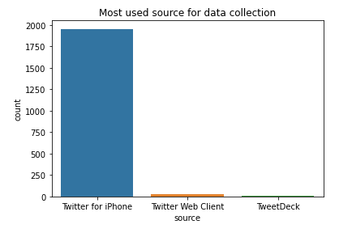

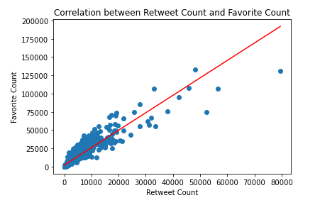